Imane Aghmari  
Fayyaz Mohammad Ali  
Farid El Attaoui

# TP Large Scale Kernel Methods

```python
import numpy as np
from scipy import linalg
import matplotlib.pyplot as plt
plt.style.use('ggplot')

from sklearn.model_selection import train_test_split
from sklearn.preprocessing import StandardScaler
from sklearn.datasets import load_svmlight_file

from sklearn.svm import LinearSVC
from sklearn.metrics import accuracy_score
from numpy.linalg import norm
from math import sqrt, pi
```

## Chargement et partitionnement des données

```python
###############################################################################
# Requires file ijcnn1.dat.gz to be present in the directory

dataset_path = 'ijcnn1.dat'
ijcnn1 = load_svmlight_file(dataset_path)
X = ijcnn1[0].todense()
y = ijcnn1[1]

###############################################################################
# Extract features

X_train, X_test, y_train, y_test = train_test_split(X[:60000, :], y[:60000],
                     train_size=20000, random_state=42)

scaler = StandardScaler()
X_train = scaler.fit_transform(X_train)
X_test = scaler.transform(X_test)

n1, p = X_train.shape
n2 = X_test.shape[0]

print("Nombre d'exemples d'apprentissage:", n1)
print("Nombre d'exemples de test:", n2)
print("Nombre de features:", p)
```

```
Nombre d'exemples d'apprentissage: 20000
Nombre d'exemples de test: 40000
Nombre de features: 22
```

## Question 1

On va fitter nos données d'apprentissage avec un SVM linéaire et un SVM non-linéaire (noyau Gaussien) pour comparer leur score de prédiction ainsi que le temps de calcul nécessaire à l'apprentissage et à la prédiction.

```python
from sklearn.svm import SVC, LinearSVC
from time import time

print("Fitting SVC rbf on %d samples..." % X_train.shape[0])
t0 = time()
# TODO
clf = SVC(kernel='rbf')
clf.fit(X_train, y_train)
print("done in %0.3fs" % (time() - t0))

print("Predicting with SVC rbf on %d samples..." % X_test.shape[0])
t1 = time()
y_pred = clf.predict(X_test)
print("done in %0.3fs" % (time() - t1))
timing_kernel_RBF = time() - t0

accuracy_kernel = accuracy_score(y_pred, y_test)
print("classification accuracy: %0.3f" % accuracy_kernel)
```

```
Fitting SVC rbf on 20000 samples...
done in 4.898s
Predicting with SVC rbf on 40000 samples...
done in 7.315s
classification accuracy: 0.980
```

```python
from sklearn.svm import SVC, LinearSVC
from time import time

print("Fitting LinearSVC on %d samples..." % X_train.shape[0])
t0 = time()
clf = LinearSVC(dual=False)
clf.fit(X_train, y_train)
print("done in %0.3fs" % (time() - t0))

print("Predicting with LinearSVC on %d samples..." % X_test.shape[0])
t1 = time()
y_pred = clf.predict(X_test)
print("done in %0.3fs" % (time() - t1))
timing_kernel_Linear = time() - t0

accuracy_linear = accuracy_score(y_pred, y_test)
print("classification accuracy: %0.3f" % accuracy_linear)
```

```
Fitting LinearSVC on 20000 samples...
done in 0.144s
Predicting with LinearSVC on 40000 samples...
done in 0.070s
classification accuracy: 0.917
```

La version linéaire de SVM est plus rapide (plus de 30 fois pour le fit), néanmoins le gain de performance se fait au détriment de la précision pusiqu'on passe de 98% à 91.7% sur la métrique accuracy.

## Question 2

On code une fonction qui calcule la meilleure approximation de rang $k$.

```python
from scipy.sparse.linalg import svds
from scipy.linalg import svd

def rank_trunc(gram_mat, k, fast=True):
    """
    k-th order approximation of the Gram Matrix G.

    Parameters
    ----------
    gram_mat : array, shape (n_samples, n_samples)
        the Gram matrix
    k : int
        the order approximation
    fast : bool
        use svd (if False) or svds (if True).

    Return
    ------
    gram_mat_k : array, shape (n_samples, n_samples)
        The rank k Gram matrix.
    """
    #if k > min(gram_mat.shape):
    #    k = min(gram_mat.shape)

    if fast:
        u, s, vt = svds(gram_mat, k=k)
        s = np.diag(s)
        gram_mat_k = u @ s @ vt
    else:
        U, s, Vh = svd(gram_mat, full_matrices=False)
        s = np.diag(s[:k])
        gram_mat_k = U[:,:k] @ s @ Vh[:k,:]

    return gram_mat_k
```

## Question 3

On applique cette fonction sur la matrice décrite dans le sujet de TP.

```python
from time import time

p = 200
r_noise = 100
r_signal = 20

intensity = 50

rng = np.random.RandomState(42)
X_noise = rng.randn(r_noise, p)
X_signal = rng.randn(r_signal, p)

gram_signal = np.dot(X_noise.T, X_noise) + intensity * np.dot(X_signal.T,
                                                              X_signal)
n_ranks = 100
ranks = np.arange(1, n_ranks + 1)
timing_fast = np.zeros(n_ranks)
timing_slow = np.zeros(n_ranks)
rel_error = np.zeros(n_ranks)

for k, rank in enumerate(ranks):
    print(k, rank)
    t0 = time()
    gram_mat_k = rank_trunc(gram_signal, rank, fast=True)
    timing_fast[k] = time() - t0

    t0 = time()
    gram_mat_k = rank_trunc(gram_signal, rank, fast=False)
    timing_slow[k] = time() - t0

    # TODO: compute relative error with Frobenius norm
    rel_error[k] = norm(gram_mat_k - gram_signal, 'fro') / norm(gram_signal, 'fro')
```

```
0 1
1 2
2 3
3 4
4 5
5 6
6 7
7 8
8 9
9 10
10 11
11 12
12 13
13 14
14 15
```

[output cut: 85 more lines]

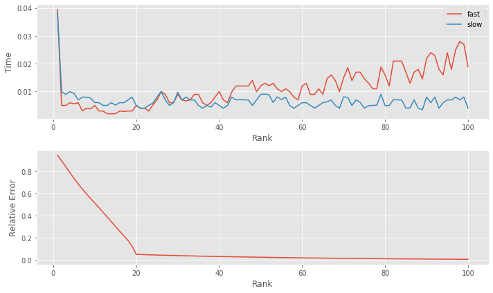

```python
###############################################################################
# Display

f, axes = plt.subplots(ncols=1, nrows=2, figsize=(10,6))#figsize=(10,6) originalement
ax1, ax2 = axes.ravel()

ax1.plot(ranks, timing_fast, '-', label='fast')
ax1.plot(ranks, timing_slow, '-', label='slow')
ax1.legend()

ax1.set_xlabel('Rank')
ax1.set_ylabel('Time')
ax2.plot(ranks, rel_error, '-')
ax2.set_xlabel('Rank')
ax2.set_ylabel('Relative Error')
plt.tight_layout()
plt.show()
```

```python
for k in np.arange(1, n_ranks):
    if timing_fast[k] > timing_slow[k]:
        print(k)
        break
```

```
19
```

## Question 4

On va implémenter l'algorithme de Random Kernel Features pour le noyau Gaussien.

```python
def random_features(X_train, X_test, gamma, c=300, seed=42):
    """Compute random kernel features

    Parameters
    ----------
    X_train : array, shape (n_samples1, n_features)
        The train samples.
    X_test : array, shape (n_samples2, n_features)
        The test samples.
    gamma : float
        The Gaussian kernel parameter
    c : int
        The number of components
    seed : int
        The seed for random number generation

    Return
    ------
    X_new_train : array, shape (n_samples1, c)
        The new train samples.
    X_new_test : array, shape (n_samples2, c)
        The new test samples.
    """

    rng = np.random.RandomState(seed)
    n_samples, n_features =  X_train.shape

    W = np.sqrt(2 * gamma) * np.random.randn(n_features, c)
    b = np.random.uniform(size=c,low=0, high=2*pi)

    X_new_train = np.sqrt(2/c) * np.cos(X_train @ W + b)
    X_new_test  = np.sqrt(2/c) * np.cos(X_test  @ W + b)

    return X_new_train, X_new_test
```

## Question 5

On va maintenant appliquer cette méthode avec $c=300$.

```python
n_samples, n_features = X_train.shape
n_samples_test, _ = X_test.shape
gamma = 1. / n_features


Z_train, Z_test = random_features(X_train, X_test, gamma, c=300, seed=44)

print("Fitting SVC linear on %d samples..." % n_samples)
t0 = time()
clf = LinearSVC(dual=False)
clf.fit(Z_train, y_train)
print("done in %0.3fs" % (time() - t0))

print("Predicting with SVC linear on %d samples..." % n_samples_test)
t0 = time()
accuracy = clf.score(Z_test, y_test)
print("done in %0.3fs" % (time() - t0))
print("classification accuracy: %0.3f" % accuracy)
```

```
Fitting SVC linear on 20000 samples...
done in 1.769s
Predicting with SVC linear on 40000 samples...
done in 0.039s
classification accuracy: 0.959
```

L'utilisation de l'algorithme Random Kernel Features permet d'améliorer la précision du modèle linéaire, il est évident qu'en performance on met plus de temps au vu des traitements supplémentaires, néanmoins le temps d'éxecution reste bien inférieur à SVC rbf qui est toujours un peu plus précis.

## Question 6

On implémente la méthode de Nystrom.

```python
from sklearn.metrics.pairwise import rbf_kernel

def nystrom(X_train, X_test, gamma, c=500, k=200, seed=44):
    """Compute nystrom kernel approximation

    Parameters
    ----------
    X_train : array, shape (n_samples1, n_features)
        The train samples.
    X_test : array, shape (n_samples2, n_features)
        The test samples.
    gamma : float
        The Gaussian kernel parameter
    c : int
        The number of points to sample for the approximation
    k : int
        The number of components
    seed : int
        The seed for random number generation

    Return
    ------
    X_new_train : array, shape (n_samples1, c)
        The new train samples.
    X_new_test : array, shape (n_samples2, c)
        The new test samples.
    """
    rng = np.random.RandomState(seed)
    n_samples1 = X_train.shape[0]
    idx = rng.choice(n_samples1, c)

    X_train_idx = X_train[idx, :]
    W = rbf_kernel(X_train_idx, X_train_idx, gamma=gamma)

    Vk, sigmaK, VkT = svd(W, full_matrices=False)
    Vk=Vk[:,:k]
    sigmaK = sigmaK[:k]
    sqrt_sigmaK = 1 / np.sqrt(sigmaK)

    Mk = np.matmul(Vk, np.diag(sqrt_sigmaK))

    C_train = rbf_kernel(X_train, X_train_idx, gamma=gamma)
    C_test  = rbf_kernel(X_test,  X_train_idx, gamma=gamma)

    X_new_train = np.matmul(C_train, Mk)
    X_new_test  = np.matmul(C_test , Mk)

    return X_new_train, X_new_test
```

## Question 7

On va maintenant appliquer cette méthode également avec $c=500$ et $k=300$

```python
Z_train, Z_test = nystrom(X_train, X_test, gamma, c=500, k=300, seed=44)

print("Fitting SVC linear on %d samples..." % n_samples)
t0 = time()
clf = LinearSVC(dual=False)
clf.fit(Z_train, y_train)
print("done in %0.3fs" % (time() - t0))

print("Predicting with SVC linear on %d samples..." % n_samples_test)
t0 = time()
accuracy = clf.score(Z_test, y_test)
print("done in %0.3fs" % (time() - t0))
print("classification accuracy: %0.3f" % accuracy)
```

```
Fitting SVC linear on 20000 samples...
done in 1.662s
Predicting with SVC linear on 40000 samples...
done in 0.039s
classification accuracy: 0.976
```

La méthode par approximation de Nyström donne une accuracy équivalente au noyau gaussien (à 0.004 près) tout en étant trois fois plus rapide.

## Question 8

On va maintenant réaliser une synthèse des performances des RKF et de Nystrom pour un ensemble de paramètres.

```python
ranks = np.arange(20, 600, 50)
n_ranks = len(ranks)
timing_rkf = np.zeros(n_ranks)
timing_nystrom = np.zeros(n_ranks)

accuracy_nystrom = np.zeros(n_ranks)
accuracy_rkf = np.zeros(n_ranks)

print("Training SVMs for various values of c...")

for i, c in enumerate(ranks):
    print(i, c)

    X_train_RKF, X_test_RKF = random_features(X_train, X_test, gamma, c)
    clf = LinearSVC(dual=False)
    a = time()
    clf.fit(X_train_RKF, y_train)
    pred_rkf = clf.predict(X_test_RKF)
    timing_rkf[i]=time()-a
    accuracy_rkf[i] = clf.score(X_test_RKF, y_test)


    k = c-10
    X_train_nystrom, X_test_nystrom = nystrom(X_train, X_test, gamma, c, k)
    clf = LinearSVC(dual=False)
    a = time()
    clf.fit(X_train_nystrom, y_train)
    pred_nystrom = clf.predict(X_test_nystrom)
    timing_nystrom[i]=time()-a
    accuracy_nystrom[i] = clf.score(X_test_nystrom, y_test)
```

```
Training SVMs for various values of c...
0 20
1 70
2 120
3 170
4 220
5 270
6 320
7 370
8 420
9 470
10 520
11 570
```

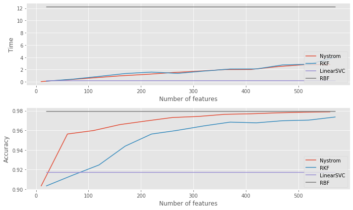

```python
###############################################################################
# Display bis

f, axes = plt.subplots(ncols=1, nrows=2, figsize=(10,6))
ax1, ax2 = axes.ravel()

ax1.plot(ranks-10, timing_nystrom, '-', label='Nystrom')
ax1.plot(ranks, timing_rkf, '-', label='RKF')
ax1.plot(ranks, timing_kernel_Linear * np.ones(n_ranks), '-', label='LinearSVC')
ax1.plot(ranks, timing_kernel_RBF * np.ones(n_ranks), '-', label='RBF')

ax1.set_xlabel('Number of features')
ax1.set_ylabel('Time')
ax1.legend(loc='lower right')

ax2.plot(ranks-10, accuracy_nystrom, '-', label='Nystrom')
ax2.plot(ranks, accuracy_rkf, '-', label='RKF')
ax2.plot(ranks, accuracy_linear * np.ones(n_ranks), '-', label='LinearSVC')
ax2.plot(ranks, accuracy_kernel * np.ones(n_ranks), '-', label='RBF')
ax2.set_xlabel('Number of features')
ax2.set_ylabel('Accuracy')
ax2.legend(loc='lower right')
plt.tight_layout()
plt.show()
```

En précision l'approximation de Nyström atteint le meme niveau de précision que le noyau Gaussien (RBF) pour number of features = 500. En terme de performance, l'approximation de Nyström est quatre fois plus rapide qu'avec le noyau Gaussien.

Random Kernel Features est un peu moins précise que l'approximation de Nyström mais du même niveau de performance.

Linear SVC reste la méthode la plus rapide mais également la moins précise de toutes.

**Probablement ajouter les notions de complexité algorithmique vues en cours afin de produire une réponse complète.**

## Pour aller plus loin

Plutot que l'utilisation d'un noyau Gaussien utilisons un noyau de Laplace dans la méthode de Nyström.

```python
from sklearn.metrics.pairwise import laplacian_kernel

def nystrom_laplace(X_train, X_test, gamma, c=500, k=200, seed=44):
    """Compute nystrom kernel approximation

    Parameters
    ----------
    X_train : array, shape (n_samples1, n_features)
        The train samples.
    X_test : array, shape (n_samples2, n_features)
        The test samples.
    gamma : float
        The Gaussian kernel parameter
    c : int
        The number of points to sample for the approximation
    k : int
        The number of components
    seed : int
        The seed for random number generation

    Return
    ------
    X_new_train : array, shape (n_samples1, c)
        The new train samples.
    X_new_test : array, shape (n_samples2, c)
        The new test samples.
    """
    rng = np.random.RandomState(seed)
    n_samples1 = X_train.shape[0]
    idx = rng.choice(n_samples1, c)

    X_train_idx = X_train[idx, :]
    W = laplacian_kernel(X_train_idx, X_train_idx, gamma=gamma)

    Vk, sigmaK, VkT = svd(W, full_matrices=False)
    Vk=Vk[:,:k]
    sigmaK = sigmaK[:k]
    sqrt_sigmaK = 1 / np.sqrt(sigmaK)

    Mk = np.matmul(Vk, np.diag(sqrt_sigmaK))

    C_train = laplacian_kernel(X_train, X_train_idx, gamma=gamma)
    C_test  = laplacian_kernel(X_test,  X_train_idx, gamma=gamma)

    X_new_train = np.matmul(C_train, Mk)
    X_new_test  = np.matmul(C_test , Mk)

    return X_new_train, X_new_test
```

On va maintenant appliquer cette méthode également avec 𝑐=500 et 𝑘=300 comme pour le kernel Gaussien

```python
Z_train, Z_test = nystrom_laplace(X_train, X_test, gamma, c=500, k=300, seed=44)

print("Fitting SVC linear on %d samples..." % n_samples)
t0 = time()
clf = LinearSVC(dual=False)
clf.fit(Z_train, y_train)
print("done in %0.3fs" % (time() - t0))

print("Predicting with SVC linear on %d samples..." % n_samples_test)
t0 = time()
accuracy = clf.score(Z_test, y_test)
print("done in %0.3fs" % (time() - t0))
print("classification accuracy: %0.3f" % accuracy)
```

```
Fitting SVC linear on 20000 samples...
done in 1.527s
Predicting with SVC linear on 40000 samples...
done in 0.039s
classification accuracy: 0.972
```

```python
ranks = np.arange(20, 600, 50)
n_ranks = len(ranks)
timing_rkf_laplace = np.zeros(n_ranks)
timing_nystrom_laplace = np.zeros(n_ranks)

accuracy_nystrom_laplace = np.zeros(n_ranks)
accuracy_rkf_laplace = np.zeros(n_ranks)

print("Training SVMs for various values of c...")

for i, c in enumerate(ranks):
    print(i, c)

    k = c-10
    X_train_nystrom_laplace, X_test_nystrom_laplace = nystrom_laplace(X_train, X_test, gamma, c, k)
    clf = LinearSVC(dual=False)
    a = time()
    clf.fit(X_train_nystrom_laplace, y_train)
    pred_nystrom_laplace = clf.predict(X_test_nystrom_laplace)
    timing_nystrom_laplace[i]=time()-a
    accuracy_nystrom_laplace[i] = clf.score(X_test_nystrom_laplace, y_test)
```

```
Training SVMs for various values of c...
0 20
1 70
2 120
3 170
4 220
5 270
6 320
7 370
8 420
9 470
10 520
11 570
```

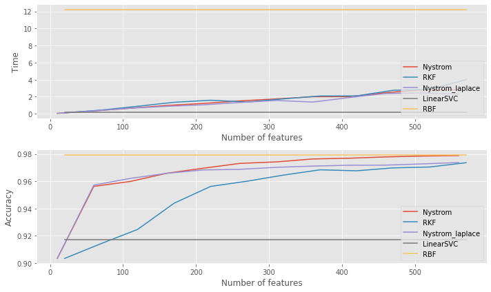

```python
###############################################################################
# Display ter

f, axes = plt.subplots(ncols=1, nrows=2, figsize=(10,6))
ax1, ax2 = axes.ravel()

ax1.plot(ranks-10, timing_nystrom, '-', label='Nystrom')
ax1.plot(ranks, timing_rkf, '-', label='RKF')
ax1.plot(ranks-10, timing_nystrom_laplace, '-', label='Nystrom_laplace')

ax1.plot(ranks, timing_kernel_Linear * np.ones(n_ranks), '-', label='LinearSVC')
ax1.plot(ranks, timing_kernel_RBF * np.ones(n_ranks), '-', label='RBF')

ax1.set_xlabel('Number of features')
ax1.set_ylabel('Time')
ax1.legend(loc='lower right')

ax2.plot(ranks-10, accuracy_nystrom, '-', label='Nystrom')
ax2.plot(ranks, accuracy_rkf, '-', label='RKF')
ax2.plot(ranks-10, accuracy_nystrom_laplace, '-', label='Nystrom_laplace')#Laplace Method

ax2.plot(ranks, accuracy_linear * np.ones(n_ranks), '-', label='LinearSVC')
ax2.plot(ranks, accuracy_kernel * np.ones(n_ranks), '-', label='RBF')
ax2.set_xlabel('Number of features')
ax2.set_ylabel('Accuracy')
ax2.legend(loc='lower right')
plt.tight_layout()
plt.show()
```

L'approximation par noyau de Laplace est équivalente au noyau Gaussien en terme de performance mais moins bonne que le noyau Gaussien en précision.

## Concaténation de noyaux

```python
RKF=False

Z_train_nystrom, Z_test_nystrom = nystrom(X_train, X_test, gamma, c=300, k=300, seed=44)
Z_train_nystrom_laplace, Z_test_nystrom_laplace = nystrom_laplace(X_train, X_test, gamma, c=300, k=300, seed=44)

if RKF:
    Z_train_RKF, Z_test_RKF = random_features(X_train, X_test, gamma, c)
    Z_train = np.concatenate((Z_train_RKF, Z_train_nystrom, Z_train_nystrom_laplace), axis=1)
    Z_test  = np.concatenate((Z_test_RKF, Z_test_nystrom, Z_test_nystrom_laplace), axis=1)
else:
    Z_train = np.concatenate(( Z_train_nystrom, Z_train_nystrom_laplace), axis=1)
    Z_test  = np.concatenate(( Z_test_nystrom,  Z_test_nystrom_laplace),  axis=1)


print("Fitting SVC linear on %d samples..." % n_samples)
t0 = time()
clf = LinearSVC(dual=False)
clf.fit(Z_train, y_train)
print("done in %0.3fs" % (time() - t0))

print("Predicting with SVC linear on %d samples..." % n_samples_test)
t0 = time()
accuracy = clf.score(Z_test, y_test)
print("done in %0.3fs" % (time() - t0))
print("classification accuracy: %0.3f" % accuracy)
```

```
Fitting SVC linear on 20000 samples...
done in 3.026s
Predicting with SVC linear on 40000 samples...
done in 0.069s
classification accuracy: 0.979
```

```python
Z_train = np.concatenate(( Z_train_nystrom, Z_train_nystrom_laplace), axis=1)
```

```python
Z_train.shape
```

```
(20000, 600)
```

Pour k=300, la méthode par concaténation de noyaux égale en précision le SVM avec noyau Gaussien.

```python
ranks = np.arange(20, 600, 50)
n_ranks = len(ranks)
timing_concat = np.zeros(n_ranks)
accuracy_concat = np.zeros(n_ranks)

print("Training SVMs for various values of c...")

for i, c in enumerate(ranks):
    print(i, c)

    X_train_nystrom, X_test_nystrom                 = nystrom(X_train, X_test, gamma, c, k=c-10)
    X_train_nystrom_laplace, X_test_nystrom_laplace = nystrom_laplace(X_train, X_test, gamma, c, k=c-10)

    if RKF:
        X_train_RKF, X_test_RKF = random_features(X_train, X_test, gamma, c)
        X_train_concat = np.concatenate((X_train_RKF,X_train_nystrom, X_train_nystrom_laplace), axis=1)
        X_test_concat = np.concatenate((X_test_RKF,X_test_nystrom, X_test_nystrom_laplace), axis=1)
    else:
        X_train_concat = np.concatenate((X_train_RKF,X_train_nystrom, X_train_nystrom_laplace), axis=1)
        X_test_concat = np.concatenate((X_test_RKF,X_test_nystrom, X_test_nystrom_laplace), axis=1)


    clf = LinearSVC(dual=False)
    a = time()
    clf.fit(X_train_concat, y_train)
    pred_concat = clf.predict(X_test_concat)
    timing_concat[i]=time()-a
    accuracy_concat[i] = clf.score(X_test_concat, y_test)
```

```
Training SVMs for various values of c...
0 20
1 70
2 120
3 170
4 220
5 270
6 320
7 370
8 420
9 470
10 520
11 570
```

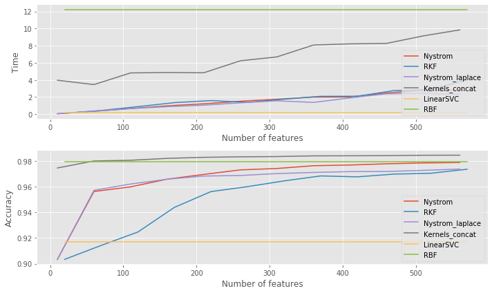

```python
###############################################################################
# Display quater

f, axes = plt.subplots(ncols=1, nrows=2, figsize=(10,6))
ax1, ax2 = axes.ravel()

ax1.plot(ranks-10, timing_nystrom, '-', label='Nystrom')
ax1.plot(ranks, timing_rkf, '-', label='RKF')
ax1.plot(ranks-10, timing_nystrom_laplace, '-', label='Nystrom_laplace')
ax1.plot(ranks-10, timing_concat, '-', label='Kernels_concat')#ranks-10

ax1.plot(ranks, timing_kernel_Linear * np.ones(n_ranks), '-', label='LinearSVC')
ax1.plot(ranks, timing_kernel_RBF * np.ones(n_ranks), '-', label='RBF')

ax1.set_xlabel('Number of features')
ax1.set_ylabel('Time')
ax1.legend(loc='lower right')

ax2.plot(ranks-10, accuracy_nystrom, '-', label='Nystrom')
ax2.plot(ranks, accuracy_rkf, '-', label='RKF')
ax2.plot(ranks-10, accuracy_nystrom_laplace, '-', label='Nystrom_laplace')#Laplace Method
ax2.plot(ranks-10, accuracy_concat, '-', label='Kernels_concat')#Concatenation Method #ranks-10

ax2.plot(ranks, accuracy_linear * np.ones(n_ranks), '-', label='LinearSVC')
ax2.plot(ranks, accuracy_kernel * np.ones(n_ranks), '-', label='RBF')
ax2.set_xlabel('Number of features')
ax2.set_ylabel('Accuracy')
ax2.legend(loc='lower right')
plt.tight_layout()
plt.show()
```

La concaténation fournit des résultats d'accuracy meilleurs que le noyau Gaussien et cela dès que l'on dépasse 200 itérations. Les performances (temps de CPU) sont meilleures aussi néanmoins l'implémentation n'est pas optimisée, on doit pouvoir mieux faire.